# assignment

Plotting just the averages:

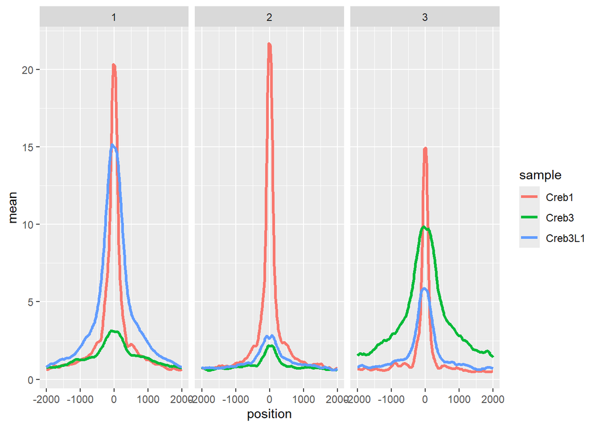

```r
#Here see it in relation
d <- meltSignals(ese, splitBy=cl)
ggplot(d, aes(position, mean, colour=sample)) + geom_line(size=1.2) + facet_wrap(~split)
```

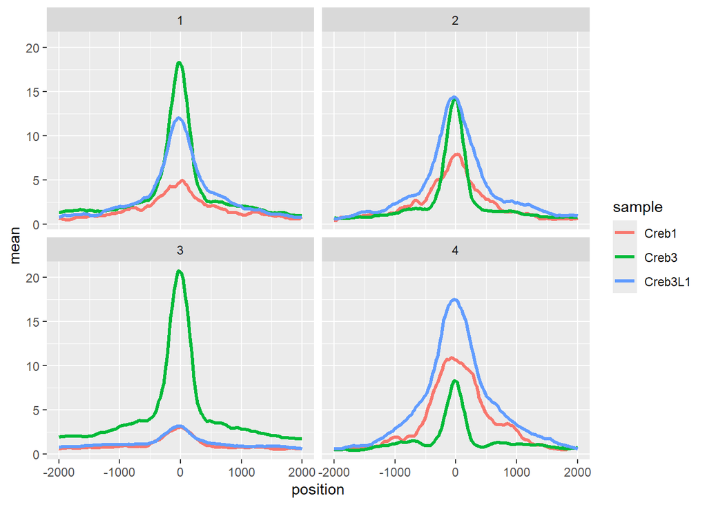

```r
d3 <- meltSignals(ese3, splitBy=cl3)
ggplot(d3, aes(position, mean, colour=sample)) + geom_line(size=1.2) + facet_wrap(~split)
```

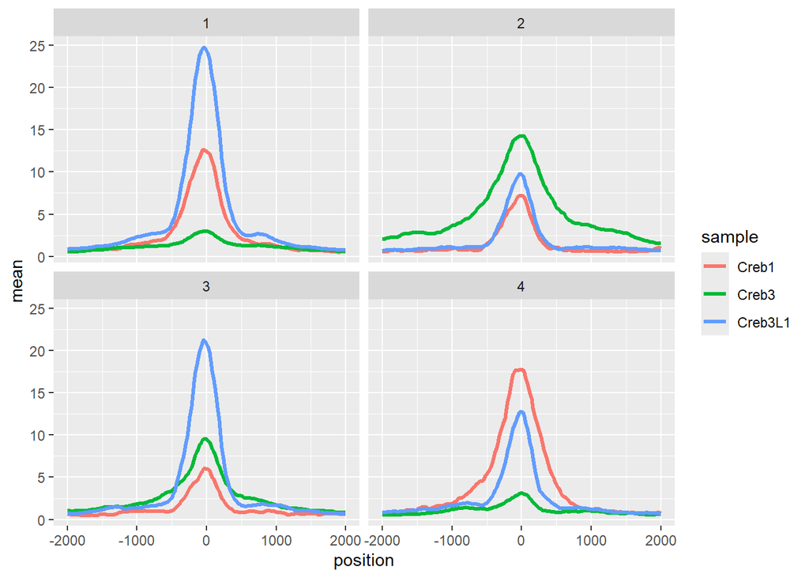

```r
d3L <- meltSignals(ese3L, splitBy=cl3L)
ggplot(d3L, aes(position, mean, colour=sample)) + geom_line(size=1.2) + facet_wrap(~split)
```

Creb1 shares some peaks with Creb3L1 or binds exclusively, a smaller proportion is also bound by both other TFs. Creb3 has a group of exclusive peaks but also has some shared peaks, these look a bit more diffuse and not as specific for any of the TFs. Creb3L has peaks that are pretty exclusive to it but also seems to follow the other two TFs in their binding at other sites.